# IODS course project

Antti Ketola

# About the project

**Introduction to Open Data Science** tackles the issues relating to open data, open science and data science.

The course deals with topics such as using tools and methods (RStudio, Rmarkdown and GitHub), regression and model validation, logistic regression, clustering and classification, discriminant analysis, K-means clustering, dimensional reduction techniques and much more.

[GitHub repository for this project](https://github.com/anketola/IODS-project)

# Data analysis for week 2

*Describe the work you have done this week and summarize your learning.*

The dataset used in the analysis here is a subset of data collected by Kimmo Vehkalahti, part of ASSIST (Approaches and Study Skills Inventory for Students) 2014. Detailed information about the original dataset can be found [here](http://www.helsinki.fi/~kvehkala/JYTmooc/JYTOPKYS3-meta.txt).

The original data had 183 observations and 60 variables.

## 1. Exploring the structure and dimensions of the data

The data has gone through a wrangling process. **The wrangling script and output dataset can be found in the GitHub respository (data -folder).** First we will load the wrangled data using R. The file is saved in a local path data/learning2014.csv. The data is loaded with the following command.

```r
lrn14 <- read.csv(file = "data/learning2014", header = TRUE)
```

Next we proceed to examine the structure and dimensions. First we invoke command dim() the loaded to dataset to get an idea of the rows and columns in the dataset.

```r
dim (lrn14)
```

```
## [1] 166   7
```

As we can see, the data has gone down from the original 183 observations and 60 variables to 166 observations and 7 variables. The observations where participants have scored of 0 have been removed, and variables have been combined to “deep”, “stra” and “surf” variables based on the questions.

Next we will have a closer look at the structure of the dataset with str() command

```r
str (lrn14)
```

```
## 'data.frame':    166 obs. of  7 variables:
##  $ gender  : Factor w/ 2 levels "F","M": 1 2 1 2 2 1 2 1 2 1 ...
##  $ age     : int  53 55 49 53 49 38 50 37 37 42 ...
##  $ attitude: num  3.7 3.1 2.5 3.5 3.7 3.8 3.5 2.9 3.8 2.1 ...
##  $ deep    : num  3.58 2.92 3.5 3.5 3.67 ...
##  $ stra    : num  3.38 2.75 3.62 3.12 3.62 ...
##  $ surf    : num  2.58 3.17 2.25 2.25 2.83 ...
##  $ points  : int  25 12 24 10 22 21 21 31 24 26 ...
```

As can been seen from the output, we have the following seven variables in the dataset: gender(“F”,“M”), age, attitude, deep, stra, surf, points.

The variables “deep”, “stra”, and “surf” are combinations of results to questions regarding deep, strategic and surface approaches to learning. The points variable indicates exam points.

The variable attitude indicates global attitude towards statistics. The variable is a result of 10 different questions (as a sum), and was scaled back to 1-5 scale during the wrangling process.

## 2. Graphical overview and summaries

We can get a graphical overview of the data using R.

For this we will use ggplot2 and GGally libraries. We can access them by using the following commands.

```r
library(ggplot2)
library(GGally)
```

Next we will create a plot matrix with all variables, genders being seperated by colors.

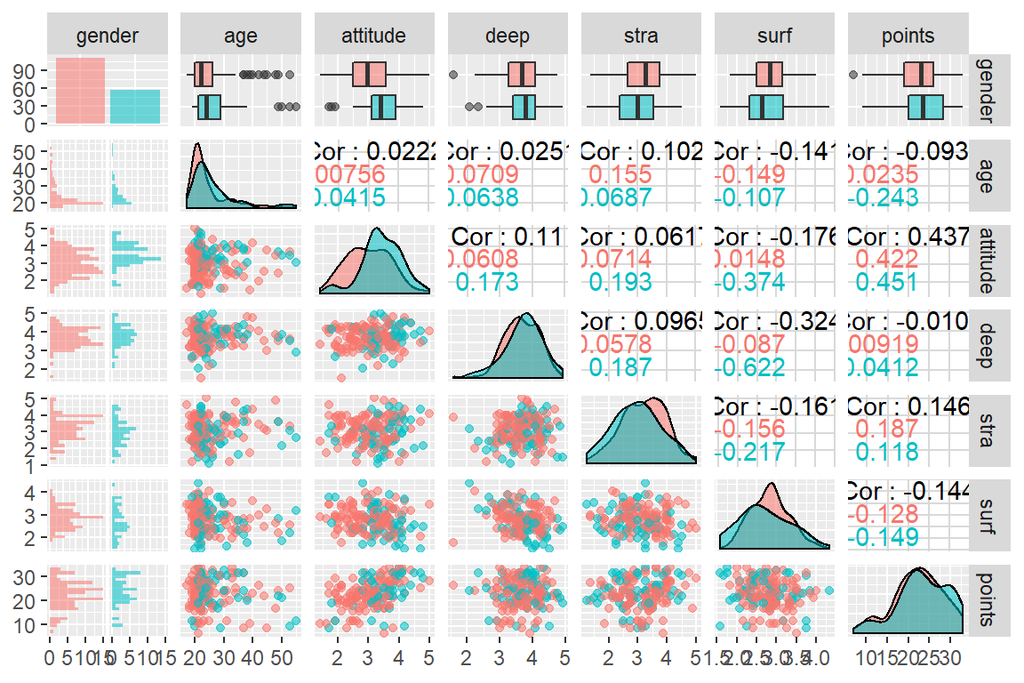

```r
ggpairs(lrn14, mapping = aes(col = gender, alpha = 0.3), lower = list(combo = wrap("facethist", bins = 20)))
```

For a numerical overview of the data, we can use the summary command.

```r
summary(lrn14)
```

```
##  gender       age           attitude          deep            stra
##  F:110   Min.   :17.00   Min.   :1.400   Min.   :1.583   Min.   :1.250
##  M: 56   1st Qu.:21.00   1st Qu.:2.600   1st Qu.:3.333   1st Qu.:2.625
##          Median :22.00   Median :3.200   Median :3.667   Median :3.188
##          Mean   :25.51   Mean   :3.143   Mean   :3.680   Mean   :3.121
##          3rd Qu.:27.00   3rd Qu.:3.700   3rd Qu.:4.083   3rd Qu.:3.625
##          Max.   :55.00   Max.   :5.000   Max.   :4.917   Max.   :5.000
##       surf           points
##  Min.   :1.583   Min.   : 7.00
##  1st Qu.:2.417   1st Qu.:19.00
##  Median :2.833   Median :23.00
##  Mean   :2.787   Mean   :22.72
##  3rd Qu.:3.167   3rd Qu.:27.75
##  Max.   :4.333   Max.   :33.00
```

Description and interpretation of outputs:

As can been seen from the outputs, majority of the participants were female (F:110, M 56). The mean age has been 25.51 and median 22. The age is most likely explained by the fact that most participants have been university students, and the variable is in the typical range for it.

Highest correlation is between attitude and exam points (0.437), indicating a possible, somewhat moderate positive relationship. The correlations between different types of learning strategies and exam results are rather low.

## 3. Three explanatory variables with exam points as the target variable

(Parts 3 and 4 of the weekly assignment)

In this part we will choose three variables as explanatory variables and fit a linear regression model with points being the target variable.

For this part of the exercise I choose attitude, age and deep as the explanatory variables. To create a regression model with multiple explanatory values, we invoce lm() command. The first parameter is in format Y ~ X. Y is the target variable so it will be set to “point”. Since we use multiple explanatory variables, we substitute X with the three chosen explanatory values. To get a summary for the model we invoke the summary() command. We run the following script for all this:

```r
my_model <- lm(points ~ attitude + age + deep, data = lrn14)
summary(my_model)
```

```
##
## Call:
## lm(formula = points ~ attitude + age + deep, data = lrn14)
##
## Residuals:
##     Min      1Q  Median      3Q     Max
## -17.206  -3.430   0.204   3.979  10.950
##
## Coefficients:
##             Estimate Std. Error t value Pr(>|t|)
## (Intercept) 15.60773    3.38966   4.605 8.32e-06 ***
## attitude     3.59413    0.56959   6.310 2.56e-09 ***
## age         -0.07716    0.05322  -1.450    0.149
## deep        -0.60275    0.75031  -0.803    0.423
## ---
## Signif. codes:  0 '***' 0.001 '**' 0.01 '*' 0.05 '.' 0.1 ' ' 1
##
## Residual standard error: 5.307 on 162 degrees of freedom
## Multiple R-squared:  0.2043, Adjusted R-squared:  0.1896
## F-statistic: 13.87 on 3 and 162 DF,  p-value: 4.305e-08
```

The summary displays information on our model where target variable is points and explanatory values attitude, age and deep. The summary displays the residualds for the model and the coefficients. We can use the coefficients to interpret the parameters for the model.

We now have for each explanatory variables the estimatated effect, the standard error for it, and t- and p-values. We are especially interested in the P-values here to be as small as possible. We cam see that attitude has a very low value, with significance code 0, indicating statistican significance. Age has P-value of 0.15 and deep 0.42.

Next we will refit the model by removing explanatory variables without statistical signigifance. As especially deep doesn’t have an statistically significant relationship with the target value, we remove it. The assignment doesn’t clearly specify if we can remove multiple variables “if an explanaotry value”, so I chose to remove only the least significant attribute. We create and display a summary of the new model with the following script:

```r
my_model2 <- lm(points ~ attitude + age, data = lrn14)
summary(my_model2)
```

```
##
## Call:
## lm(formula = points ~ attitude + age, data = lrn14)
##
## Residuals:
##      Min       1Q   Median       3Q      Max
## -17.3354  -3.3095   0.2625   4.0005  10.4911
##
## Coefficients:
##             Estimate Std. Error t value Pr(>|t|)
## (Intercept) 13.57244    2.24943   6.034 1.04e-08 ***
## attitude     3.54392    0.56553   6.267 3.17e-09 ***
## age         -0.07813    0.05315  -1.470    0.144
## ---
## Signif. codes:  0 '***' 0.001 '**' 0.01 '*' 0.05 '.' 0.1 ' ' 1
##
## Residual standard error: 5.301 on 163 degrees of freedom
## Multiple R-squared:  0.2011, Adjusted R-squared:  0.1913
## F-statistic: 20.52 on 2 and 163 DF,  p-value: 1.125e-08
```

The fitted model has still a strong statistical significance for attitude attribute with age remaining rather same. It’s somewhat questionable if the age should be part of the model.

From the summary we can see examine the multiple R squared of the model. The definition of R squared is explained variation / total variation. Generally a higher R value means a better fit. For the model we have R squared value of 0.20.

## 4. Diagnostic plots

Next we will generate three diagnostic plots: Residuals vs Fitted values, Normal QQ-plot and Residuals vs Leverage.

To do this weuse the plot() function and choose with “which” argument the needed plots. In this case the code and output is the following:

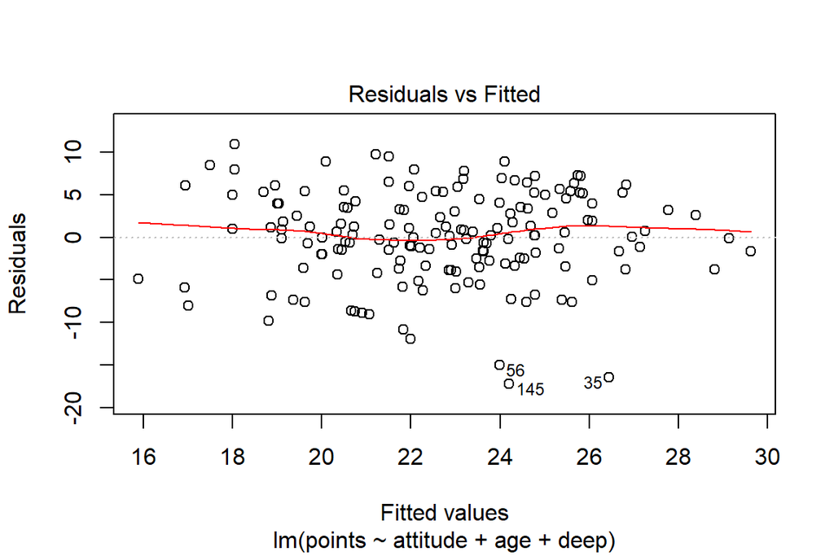

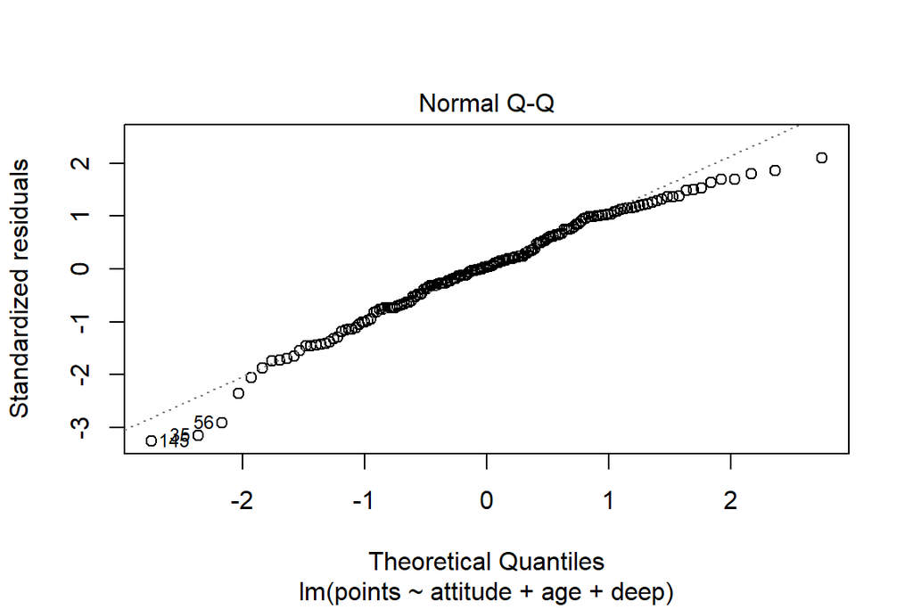

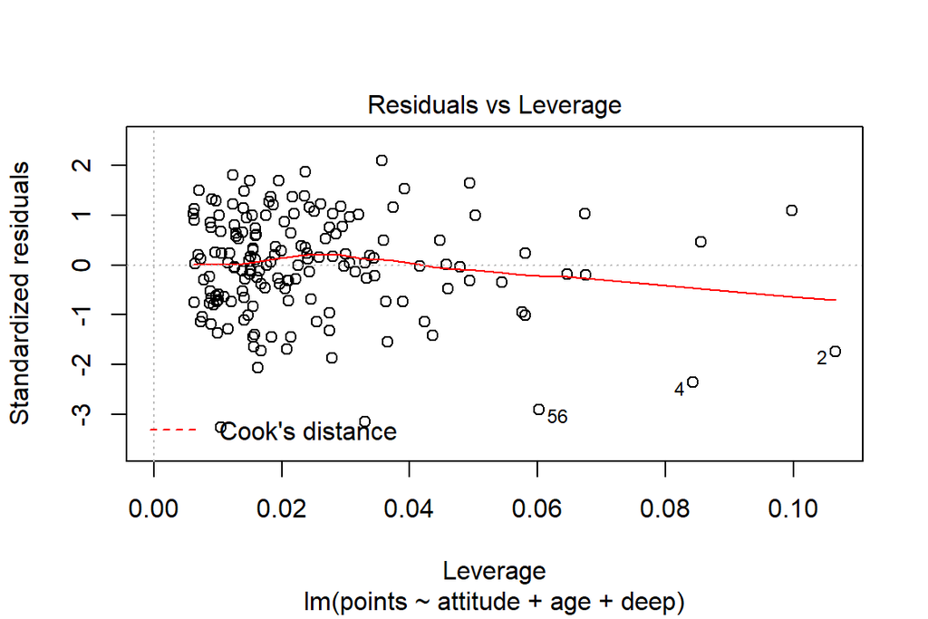

```r
plot(my_model, which=c(1:2,5))
```

Residuals vs. fitted values:

The size of the errors should not depend on the expanatory values. Although the distribution is rather random, there are some observations with very high residual especially in the 20+ fitted value range.

Normal QQ-plot:

From the QQ plot we can explore if the errors in the model are normally distributed. Based on the QQ-plot, we can see the fit with is good especially in the mid-section. There is slight deviation in the low and high ranges, but overall the model seems to be a good fit.

Residuals vs Leverage:

The plot containging Residuals vs Leverage can be used to examine if some observations have particulary high impact. As we can see from the chart, there are some outliers with high impact. However, the outliers seem to be rather evenly distributed.

# Data analysis for week 3

The week 3 uses a dataset from UCL Machine Learning Respository by P. Cortez and A. Silva. More information can be found by clicking [here](https://archive.ics.uci.edu/ml/datasets/Student+Performance).

The database has a related publication:

*P. Cortez and A. Silva. Using Data Mining to Predict Secondary School Student Performance. In A. Brito and J. Teixeira Eds., Proceedings of 5th FUture BUsiness TEChnology Conference (FUBUTEC 2008) pp. 5-12, Porto, Portugal, April, 2008. [Web Link](http://www3.dsi.uminho.pt/pcortez/student.pdf).*

## Loading and describing the data

The data being used here examined student performance in two Portuguese schools.

For this analysis, we have prepared the data through a wrangling process. We begin by loading a local dataset using read.csv() command.

```r
alc <- read.csv(file = "data/alc.CSV", header = TRUE)
```

We can see the names of the variables by examining the column names.

```r
colnames(alc)
```

```
##  [1] "school"     "sex"        "age"        "address"    "famsize"
##  [6] "Pstatus"    "Fedu"       "Medu"       "Mjob"       "Fjob"
## [11] "reason"     "nursery"    "internet"   "guardian"   "traveltime"
## [16] "studytime"  "failures"   "schoolsup"  "famsup"     "paid"
## [21] "activities" "higher"     "romantic"   "famrel"     "freetime"
## [26] "goout"      "Dalc"       "Walc"       "health"     "absences"
## [31] "G1"         "G2"         "G3"         "alc_use"    "high_use"
```

The dataset we have loaded now is a joined dataset. The joined datasets dealt with different subjects, one with Mathematics and the other with Portuguese language. Details of the dataset variables can be found [here](https://archive.ics.uci.edu/ml/datasets/Student+Performance).

As an overview, the data has background information on parents such as familysize (famsize -> LE3 if less or equal to 3, otherwise GT3), parents cohabitation status (Pstatus, binary Together/Apart), mother’s and father’s education (Medu, Fedu) and job (Mjob, Fjob), who the guardian is (guardian: “mother”, “father”, “other”). Information regarding the student concern home to school travel time (traveltime), weekly study time (study), number of past class failures (failures) etc.

Compared to the original data (which can be found ), there are some changes. For instance, the variable alc_use, that is not in the original dataset, is an average of the weekday and weekday usage. This variable has been used to create the a new logical variable high_use, which is TRUE in case the alc_use is higher than 2, otherwise alc_use is FALSE.

## Studying the relationship between alcohol consumption and other variables

Next will be selected 4 variables and their relationship with alcohol consuption will be examined.

1. First we will choose “studytime”, which indicates weekly study time. The hypothesis here is that those spending more time studying will consume less alcohol.
2. The second varible is “goout”. As alchohol is likely to be consumed and obtained when hanging out with friends, this will be connected to alcohol use.
3. For the third variable is chosen “absences” which indicates the number of school absences (numeric from 0 to 93). The hypothesis is that absences is higher for those who are high alcohol users.
4. And as the last variable is chosen “famrel” which measures family realitonships on the scale from 1 (very bad) to 5 (excellent). Alcohol use might be caused by bad family relationship issues. Also he use of alcohol might affect the relationships negatively.

## Exploring the distributions and relationships of chosen variables with alcohol consumption

We are going to add some libraries into use.

```r
library(ggplot2)
library(dplyr)
```

Next, we will examine each chosen variable in relationship to alc_high. First let’s have a look at the numerical summary. Instead of alc_high, we look at the alc_use variable.

```r
temp_alc <- data.frame(alc$studytime, alc$goout, alc$absences, alc$famrel, alc$alc_use)
summary(temp_alc)
```

```
##  alc.studytime     alc.goout      alc.absences    alc.famrel
##  Min.   :1.000   Min.   :1.000   Min.   : 0.0   Min.   :1.000
##  1st Qu.:1.000   1st Qu.:2.000   1st Qu.: 1.0   1st Qu.:4.000
##  Median :2.000   Median :3.000   Median : 3.0   Median :4.000
##  Mean   :2.037   Mean   :3.113   Mean   : 4.5   Mean   :3.937
##  3rd Qu.:2.000   3rd Qu.:4.000   3rd Qu.: 6.0   3rd Qu.:5.000
##  Max.   :4.000   Max.   :5.000   Max.   :45.0   Max.   :5.000
##   alc.alc_use
##  Min.   :1.000
##  1st Qu.:1.000
##  Median :1.500
##  Mean   :1.889
##  3rd Qu.:2.500
##  Max.   :5.000
```

Goout and famrel variables have rather high values. Especially famrel seems to be high, with median of 4.0 and mean of 3.9. Studytime has the median of 2.0 and median of 2.0. Not much conclusions can be drawn from this. We will now inspect each variable in relationship to alc_high. Absences has median of 3 and mean of 4.5. The max value for absences was 45, and 3rd quartile 6.0. The values for absences can be viewed either as a positive, depending on the viewpoint. Absences might be highly connected with the health variable, but we are not examining that right now. Not many conclusiosn can be drawn from this data. We will next view each variable seperately in connection to high_alc.

#### *Studytime -variable.*

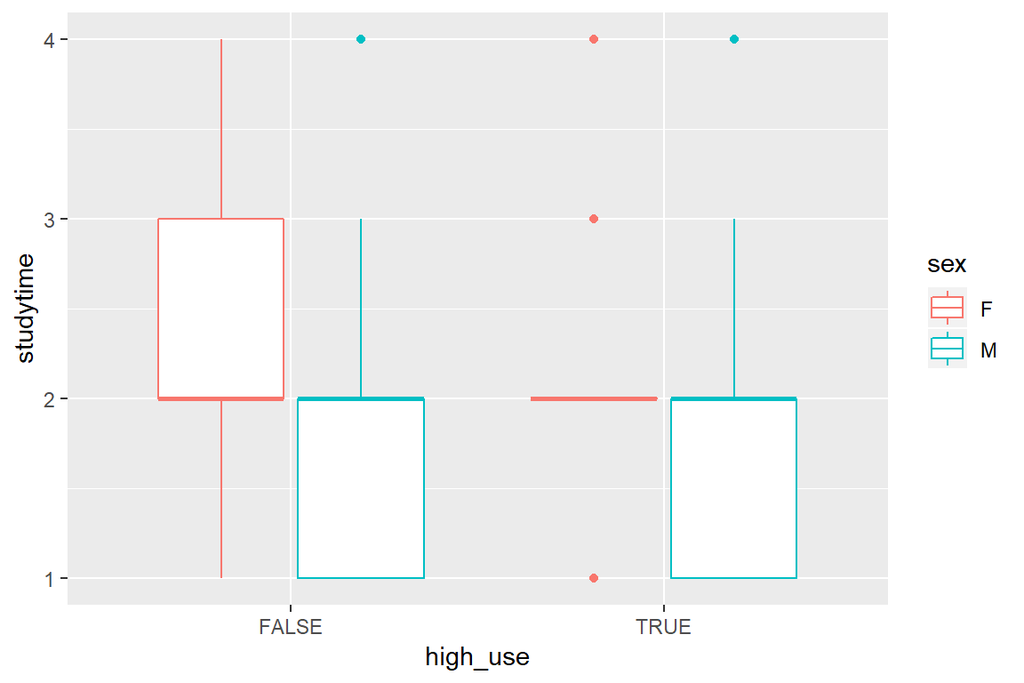

```r
p1 <- ggplot(alc, aes(x = high_use, y = studytime, col = sex))
p1 + geom_boxplot()
```

```r
alc %>% group_by(high_use) %>% summarise(count = n(), mean_studytime = mean(studytime))
```

```
## # A tibble: 2 x 3
##   high_use count mean_studytime
##   <lgl>    <int>          <dbl>
## 1 FALSE      268           2.15
## 2 TRUE       114           1.77
```

Based on this the hypothesis 1 appears to be true. Those who are in the alc_high group spend less time studying.

#### *Goout -variable.*

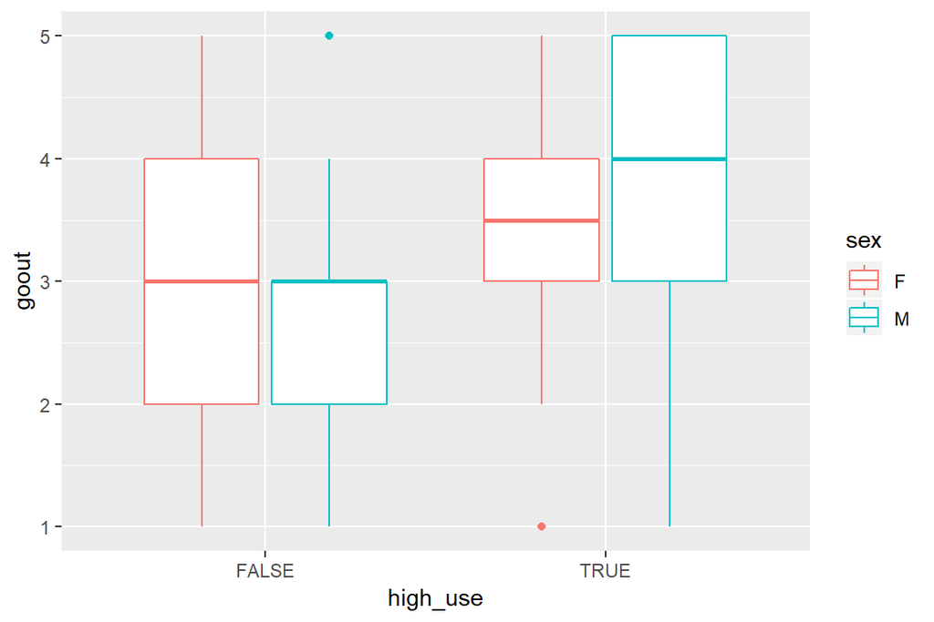

```r
p1 <- ggplot(alc, aes(x = high_use, y = goout, col = sex))
p1 + geom_boxplot()
```

```r
alc %>% group_by(high_use) %>% summarise(count = n(), mean_goout = mean(goout))
```

```
## # A tibble: 2 x 3
##   high_use count mean_goout
##   <lgl>    <int>      <dbl>
## 1 FALSE      268       2.85
## 2 TRUE       114       3.72
```

The second hypothesis was that those who go out more spend more alcohol. Although it can be said that all go out quite much, on average the high-users spend more time out. The hypothesis was therefore correct.

#### *Absences -variable.*

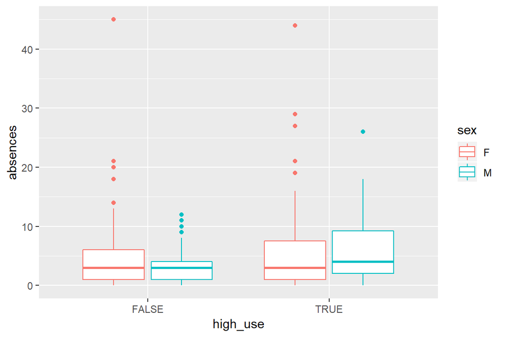

```r
p1 <- ggplot(alc, aes(x = high_use, y = absences, col = sex))
p1 + geom_boxplot()
```

```r
alc %>% group_by(high_use) %>% summarise(count = n(), mean_absences = mean(absences))
```

```
## # A tibble: 2 x 3
##   high_use count mean_absences
##   <lgl>    <int>         <dbl>
## 1 FALSE      268          3.71
## 2 TRUE       114          6.37
```

Perhaps not surprisingly, those who are high alcohol users have more absences. There seems to be some differences in relation to sex based on the graph. We reiterate the text part with more seperation:

```r
alc %>% group_by(sex, high_use) %>% summarise(count = n(), mean_absences = mean(absences))
```

```
## # A tibble: 4 x 4
## # Groups:   sex [?]
##   sex   high_use count mean_absences
##   <fct> <lgl>    <int>         <dbl>
## 1 F     FALSE      156          4.22
## 2 F     TRUE        42          6.79
## 3 M     FALSE      112          2.98
## 4 M     TRUE        72          6.12
```

#### *Famrel -variable.*

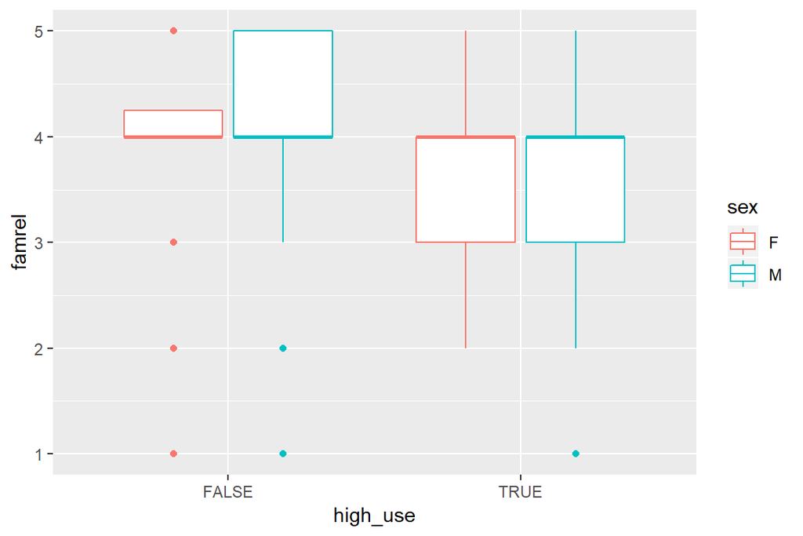

```r
p1 <- ggplot(alc, aes(x = high_use, y = famrel, col = sex))
p1 + geom_boxplot()
```

```r
alc %>% group_by(high_use) %>% summarise(count = n(), mean_famrel = mean(famrel))
```

```
## # A tibble: 2 x 3
##   high_use count mean_famrel
##   <lgl>    <int>       <dbl>
## 1 FALSE      268        4.00
## 2 TRUE       114        3.78
```

The famrel variable was hypothesized to be lower for ghigh alcohol users. This seems to be the case, although the difference is not that prominent. However, neither group shows a significant deviation from the mean value for the famrel variable. As there seem to be some more sex related differences, we reiterate again the text table.

```r
alc %>% group_by(sex, high_use) %>% summarise(count = n(), mean_famrel = mean(famrel))
```

```
## # A tibble: 4 x 4
## # Groups:   sex [?]
##   sex   high_use count mean_famrel
##   <fct> <lgl>    <int>       <dbl>
## 1 F     FALSE      156        3.91
## 2 F     TRUE        42        3.76
## 3 M     FALSE      112        4.13
## 4 M     TRUE        72        3.79
```

The males seem to have have scored slightly higher non-high user group. Other than that, the information seems to show the fourth hypothesis was also correct, although the differences are not very drastic between high users, and low users.

## Logistic regression

As the following step we are going to use logistic regression to explore the relationship between the chosen variables and high_use. First we build a model using gml() command and then output a summary using summary() command.

```r
model1 <- glm(high_use ~ studytime + goout + absences + famrel, data = alc, family = "binomial")
summary(model1)
```

```
##
## Call:
## glm(formula = high_use ~ studytime + goout + absences + famrel,
##     family = "binomial", data = alc)
##
## Deviance Residuals:
##     Min       1Q   Median       3Q      Max
## -1.8701  -0.7738  -0.5019   0.8042   2.5416
##
## Coefficients:
##             Estimate Std. Error z value Pr(>|z|)
## (Intercept) -1.28606    0.70957  -1.812  0.06992 .
## studytime   -0.55089    0.16789  -3.281  0.00103 **
## goout        0.75953    0.12041   6.308 2.82e-10 ***
## absences     0.06753    0.02175   3.104  0.00191 **
## famrel      -0.33699    0.13681  -2.463  0.01377 *
## ---
## Signif. codes:  0 '***' 0.001 '**' 0.01 '*' 0.05 '.' 0.1 ' ' 1
##
## (Dispersion parameter for binomial family taken to be 1)
##
##     Null deviance: 465.68  on 381  degrees of freedom
## Residual deviance: 384.07  on 377  degrees of freedom
## AIC: 394.07
##
## Number of Fisher Scoring iterations: 4
```

We will output the coefficients using coef() command.

```r
coef(model1)
```

```
## (Intercept)   studytime       goout    absences      famrel
## -1.28606058 -0.55089391  0.75953025  0.06753071 -0.33699130
```

Next we will compute the coefficients as odds ratios and give the confidence intervals for them, via using the following code:

```r
OR <- coef(model1) %>% exp
CI <- confint(model1) %>% exp
```

The odds ratios and their confidence intervals are output by invoking the following command:

```r
cbind (OR, CI)
```

```
##                    OR      2.5 %    97.5 %
## (Intercept) 0.2763573 0.06723596 1.0961732
## studytime   0.5764343 0.41040872 0.7941804
## goout       2.1372720 1.69853389 2.7261579
## absences    1.0698631 1.02591583 1.1187950
## famrel      0.7139151 0.54460646 0.9331198
```

The summary output indicated a statistical significance for all four variables. The highest (three stars), is for goout at less than 0.0001. The model seems to be overall rather good fit.

Coming back to the originaly hypothesis, the logistic regression model seems to fit the data relatively well.

## Predictive power / cross tabulation

In this section we exlore a cross tabulation of predictions vs. the actual values. We will will then see how many indidivuals the model classifies incorrectly. This is also known as training error. We utilize the predict() command and mutate the alc table as follows:

```r
probabilities <- predict(model1, type = "response")
alc <- mutate(alc, probability = probabilities)
alc <- mutate(alc, prediction = probability > 0.5)
```

```r
table(high_use = alc$high_use, prediction = alc$prediction)
```

```
##         prediction
## high_use FALSE TRUE
##    FALSE   242   26
##    TRUE     65   49
```

This can also be visualized with R.

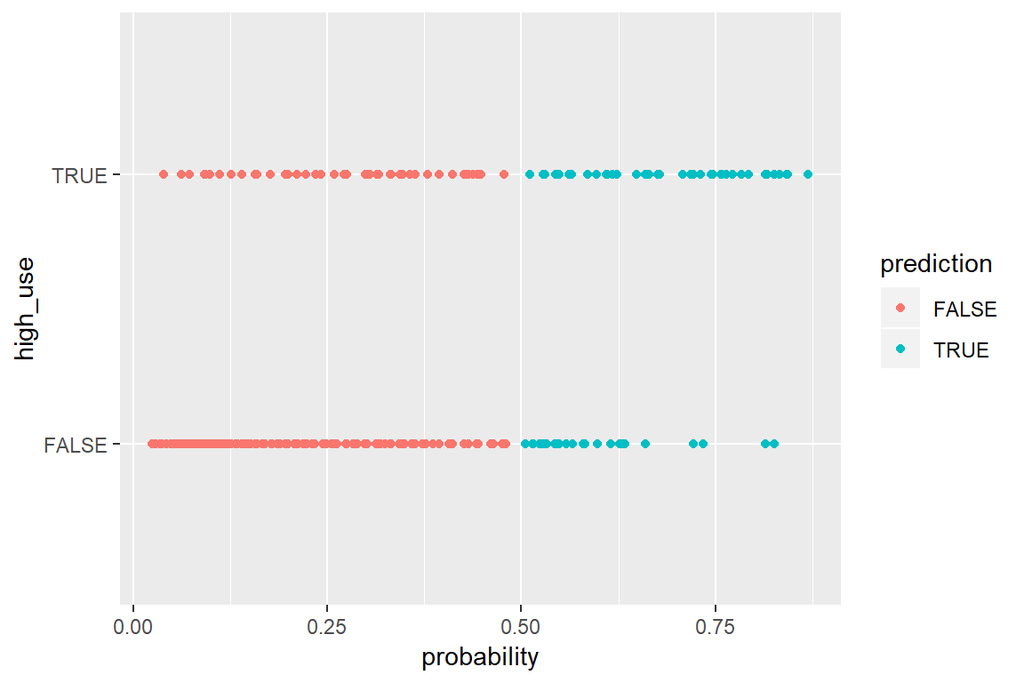

```r
p1 <- ggplot(alc, aes(x = probability, y = high_use, col = prediction))
p1 + geom_point()
```

```r
table(high_use = alc$high_use, prediction = alc$prediction) %>% prop.table() %>% addmargins()
```

```
##         prediction
## high_use      FALSE       TRUE        Sum
##    FALSE 0.63350785 0.06806283 0.70157068
##    TRUE  0.17015707 0.12827225 0.29842932
##    Sum   0.80366492 0.19633508 1.00000000
```

We create a simple loss function as instructed in the DataCamp. Then we call the function to see the output, which indicates how many wrong classifications in the prediction data is.

```r
loss_func <- function(class, prob) {
  n_wrong <- abs(class - prob) > 0.5
  mean(n_wrong)
}

loss_func(class = alc$high_use, prob = alc$probability)
```

```
## [1] 0.2382199
```

To interpret the results for this, the model has training error of 24 %. The tables above indicate how likely the model is to have false positive and false negative guesses as well. Overall the model seems to be rather accurate with the predictions.

## 10-fold cross validation

Finally we perform a 10-fold cross validation for the data and compare it to the DataCamp model. This means we “shuffle” the training set ten times. The actual data is divided into K (= 10 here) subset and each subset is used as both training set and testing set.

We include a new library called boot. For the glm function we we as parameters the data, our previously defined loss function, the model, and number of K-folds. We get the following R script:

```r
library(boot)
cv <- cv.glm(data = alc, cost = loss_func, glmfit = model1, K = 10)
cv$delta[1]
```

```
## [1] 0.2408377
```